# ALS Processing Tutorial - Part I

Author

Fabian Jörg Fischer

Published

February 24, 2026

## 1 Overview

This is a tutorial on ALS processing in R.

### 1.1 Objective

**NoteWhat this aims to be**

- a quick introduction
- overview over typical workflow
- overview over typical uncertainties and errors

**ImportantWhat this does not aim to be**

- fully developed and robust processing workflow
- full analysis framework

### 1.2 General guidance

**Useful processing maxims:**

- prefer upper canopy data over within-canopy data
- prefer simple over complex metrics
- carry out sensitivity analyses (changes in parameters, changes in data)

**Useful books/tutorials:**

- Interactive introduction by NOAA: https://coast.noaa.gov/digitalcoast/training/intro-lidar.html
- Excellent overview by NEON: https://www.neonscience.org/resources/learning-hub/tutorials/lidar-basics
- Excellent tutorial on open source processing: https://r-lidar.github.io/lidRbook/
- Standard software tool / LAStools + documentation: https://rapidlasso.de/product-overview/ + https://groups.google.com/g/lastools
- Surface models guidance: Fischer et al. 2024, Methods in Ecology and Evolution, https://doi.org/10.1111/2041-210X.14416
- 3D density processing: https://amapvox.org/

**TipPersonal Coding Preferences**

I have a few personal preferences for coding in R. These preferences will be visible in the scripts, but you do not have to follow them. In particular:

- no “tidyverse” coding (no pipes, no dplyr, etc.) except ggplot
- using data.table for non-spatial data manipulation
- using terra for spatial data manipulation
- no use of “<-” for assigning values, always using “=” operator

### 1.3 Setup and Loading Packages

```r
# standard libraries for our purposes
library(lidR) # default lidar processing software in R, rasterizes point clouds
library(terra) # for analyzing rasterized products
library(data.table) # fast data manipulation
library(ggplot2) # plotting
library(viridis) # plotting
library(patchwork) # plotting
library(RCSF) # ground classification CSF
# library(RMCC) # ground classification MCC
library(future) # parallel processing
```

## 2 Sample Data: ALS Point Clouds from G-LiHT and NEON at Harvard Forest

Throughout this document, we will focus on 8 square kilometres of forest in the U.S. The data are available [here](https://drive.google.com/file/d/1VYg0pwRWS1jPqHQ31z53nVxwl7pMmSPK/view?usp=sharing). Unzip the dowloaded folder into your working directory and keep the directory structure as it is.

### 2.1 Study Site: Harvard Forest

Located in the Worcester ecoregion, vegetation is consistent with those of transition hardwoods-white pine-hemlock forests. Due to historical logging and hurricanes, the forest is second-growth and many of the trees are under 100 years old. The dominant vegetation is regenerating Eastern Deciduous temperate forest comprised of red oak (*Quercus rubra*), red maple (*Acer rubrum*), and white pine (*Pinus strobus*). Understory shrubs, trees, ferns, and flowering herbs are common in areas with higher moisture.

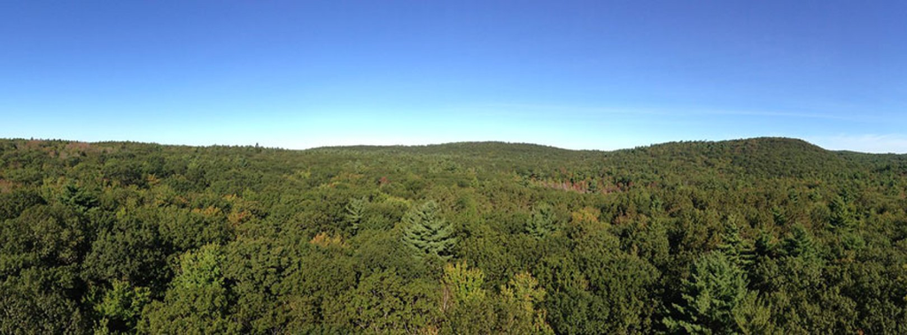

Harvard Forest canopy view

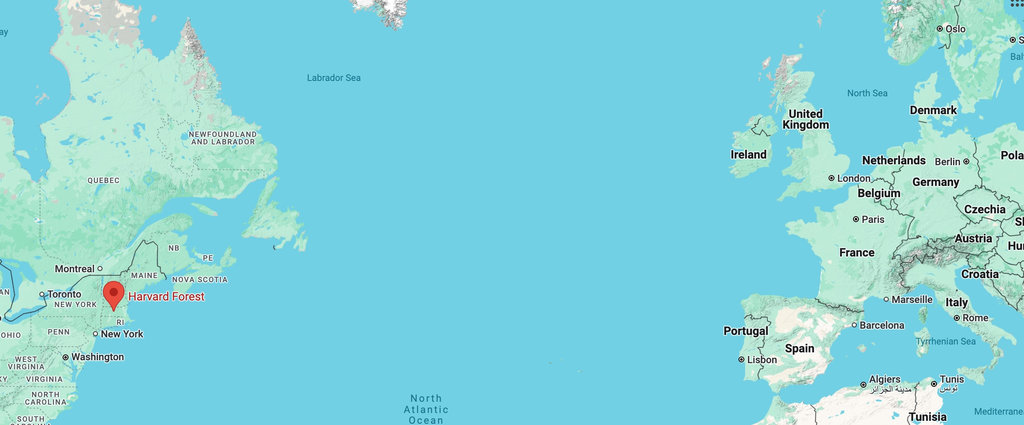

Harvard Forest location

**NoteData Source**

Directly taken from: https://www.neonscience.org/field-sites/harv

**View from above:**

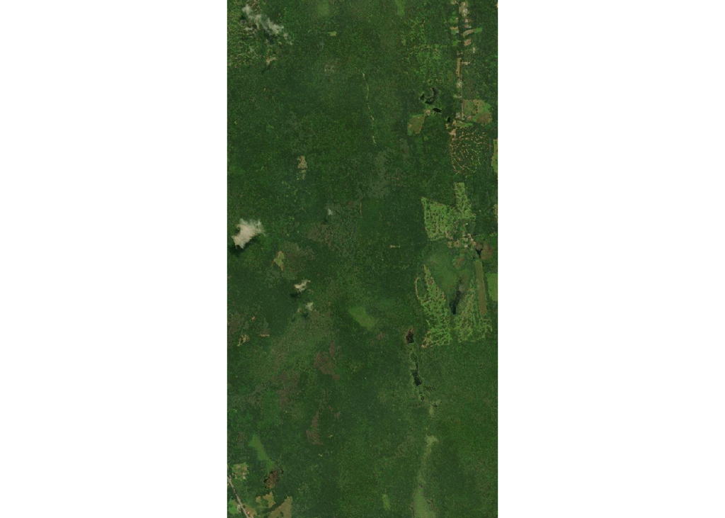

### 2.2 Data: Airborne Laser Scans

Harvard Forest is probably one of the most-scanned sites. Some parts of it have been scanned with airborne lasers 12 times between 2012 and 2024, and these are just the openly available ones.

There are three types of scanning agencies:

- **NEON**: National Ecological Observatory Network - continuous surveys of ecologically interesting sites (8 scans, all summer)
- **GLiHT**: NASA laser scanning - mostly satellite validation (3 scans, all summer)
- **3DEP**: General U.S. national survey (1 scan, winter)

## 3 Guiding Question: What is the Typical Forest Structure at Harvard Forest?

**Motivation:**

- relevance for biomass
- relevance for disturbance monitoring
- relevance for habitat/biodiversity assessments

**NotePre-Analysis Exercise**

Before diving into the data processing, consider these questions about Harvard Forest:

**Background information:** - Location: Eastern United States (Worcester ecoregion) - Climate: Temperate deciduous - Forest type: Regenerating Eastern Deciduous forest (second-growth) - Dominant species: Red oak (*Quercus rubra*), red maple (*Acer rubrum*), white pine (*Pinus strobus*) - Age: Most of the forest is roughly 100 years old (post-logging/hurricane disturbance) - Management: Ongoing management activities

**Questions to estimate (write down your answers before analyzing!):**

1. What do you expect the **maximum tree height** to be? (in meters)
2. What do you expect the **mean canopy height** to be? (in meters)
3. What do you expect the **annual height growth rate** to be for young trees (< 5m)? (in meters per year)
4. Is the forest overall **growing, balanced, or losing height**?
5. What percentage of the forest do you expect has experienced recent **disturbance** (e.g., tree falls, management)?

*Note: The actual tree maximum height limit is ~120 m (very rare trees), but most forests don’t reach anywhere close to this.*

**Processing Questions:**

- How do we process ALS point clouds to obtain reliable estimates of height?
- How do different algorithms affect our results?
- What uncertainties should we be aware of?

## 4 Processing

The different steps here are modelled on the lidR handbook (https://r-lidar.github.io/lidRbook/). For this exercise, we rely on an early NEON scan from 2012, as this is a lower quality scan and faster to process. However, for those that would like to compare two scans, there is also a GLiHT scan from 2012 in the folder.

### 4.1 Reading in Point Cloud Data and Quality Checks

When reading in point cloud data, there are several things to consider:

- **Data types**: .las, .laz, .asc, .xyz
- **Coordinate Reference Systems (CRS)**: usually UTM coordinates
- **GPS times**: GPS week time vs. adjusted standard time
- **Data quality**: pulse density (more important than point density)

```r
# read in a single tile and examine it.
las = readLAS("data/NEON/2012/731000_4712000.laz")
```

```r
# clip the tile to a smaller extent for quicker processing
las = clip_rectangle(las, 731400, 4712175, 731700, 4712475)

# check sumstats
print(las)
```

```
class        : LAS (v1.3 format 1)
memory       : 36.2 Mb
extent       : 731400, 731700, 4712175, 4712475 (xmin, xmax, ymin, ymax)
coord. ref.  : WGS 84 / UTM zone 18N
area         : 90600 m²
points       : 527.4 thousand points
type         : airborne
density      : 5.82 points/m²
density      : 2.74 pulses/m²
```

```r
summary(las)
```

```
class        : LAS (v1.3 format 1)
memory       : 36.2 Mb
extent       : 731400, 731700, 4712175, 4712475 (xmin, xmax, ymin, ymax)
coord. ref.  : WGS 84 / UTM zone 18N
area         : 90600 m²
points       : 527.4 thousand points
type         : airborne
density      : 5.82 points/m²
density      : 2.74 pulses/m²
File signature:           LASF
File source ID:           0
Global encoding:
 - GPS Time Type: GPS Week Time
 - Synthetic Return Numbers: no
 - Well Know Text: CRS is GeoTIFF
 - Aggregate Model: false
Project ID - GUID:        00000000-0000-0000-0000-000000000000
Version:                  1.3
System identifier:        LAStools (c) by rapidlasso GmbH
Generating software:      lasmerge (version 160730)
File creation d/y:        46/2018
header size:              235
Offset to point data:     575
Num. var. length record:  2
Point data format:        1
Point data record length: 32
Num. of point records:    527426
Num. of points by return: 248117 174886 80035 24388 0
Scale factor X Y Z:       0.01 0.01 0.01
Offset X Y Z:             7e+05 4700000 0
min X Y Z:                731400 4712175 339.77
max X Y Z:                731700 4712475 383.41
Variable Length Records (VLR):
   Variable Length Record 1 of 2
       Description:
       Tags:
          Key 1024 value 1
          Key 1025 value 2
          Key 3072 value 32618
          Key 4099 value 9001
   Variable Length Record 2 of 2
       Description: by LAStools of rapidlasso GmbH
       Extra Bytes Description:
          reversible index (lastile): original index before tiling
Extended Variable Length Records (EVLR):  void
```

```r
# check the underlying structure (data.table)
las_dt = las@data
class(las_dt)
```

```
[1] "data.table" "data.frame"
```

```r
str(las_dt)
```

```
Classes 'data.table' and 'data.frame':  527426 obs. of  17 variables:
 $ X                         : num  731682 731683 731684 731686 731686 ...
 $ Y                         : num  4712175 4712176 4712176 4712176 4712176 ...
 $ Z                         : num  355 352 352 352 356 ...
 $ gpstime                   : num  217776 217776 217776 217776 217776 ...
 $ Intensity                 : int  1 1 2 19 18 20 10 17 1 5 ...
 $ ReturnNumber              : int  2 3 2 3 2 3 2 3 2 2 ...
 $ NumberOfReturns           : int  3 3 2 3 3 3 3 3 2 2 ...
 $ ScanDirectionFlag         : int  0 0 0 0 0 0 0 0 0 0 ...
 $ EdgeOfFlightline          : int  0 0 0 0 0 0 0 0 0 0 ...
 $ Classification            : int  5 2 2 2 5 2 5 2 2 5 ...
 $ Synthetic_flag            : logi  FALSE FALSE FALSE FALSE FALSE FALSE ...
 $ Keypoint_flag             : logi  FALSE FALSE FALSE FALSE FALSE FALSE ...
 $ Withheld_flag             : logi  FALSE FALSE FALSE FALSE FALSE FALSE ...
 $ ScanAngleRank             : int  -20 -20 -20 -20 -20 -20 -20 -20 -20 -21 ...
 $ UserData                  : int  33 0 0 0 31 0 37 0 0 127 ...
 $ PointSourceID             : int  2 2 2 2 2 2 2 2 2 2 ...
 $ reversible index (lastile): int  756865478 756865479 756865481 756865485 756865487 756865488 756865490 756865491 756865493 756865505 ...
 - attr(*, ".internal.selfref")=<externalptr>
```

We can visualize the point cloud:

```r
# visualize the point cloud
# this may not work, especially for large point clouds
plot(las)
```

We can automatically check the quality of the files:

```r
# check quality
las_check(las)
```

```
 Checking the data
  - Checking coordinates... ✓
  - Checking coordinates type... ✓
  - Checking coordinates range... ✓
  - Checking coordinates quantization... ✓
  - Checking attributes type... ✓
  - Checking ReturnNumber validity... ✓
  - Checking NumberOfReturns validity... ✓
  - Checking ReturnNumber vs. NumberOfReturns... ✓
  - Checking RGB validity... ✓
  - Checking absence of NAs... ✓
  - Checking duplicated points...
    ⚠ 14 points are duplicated and share XYZ coordinates with other points
  - Checking degenerated ground points...
    ⚠ There were 12 degenerated ground points. Some X Y coordinates were repeated but with different Z coordinates
  - Checking attribute population... ✓
  - Checking gpstime incoherances ✓
  - Checking flag attributes... ✓
  - Checking user data attribute...
    🛈 480222 points have a non 0 UserData attribute. This probably has a meaning
 Checking the header
  - Checking header completeness... ✓
  - Checking scale factor validity... ✓
  - Checking point data format ID validity... ✓
  - Checking extra bytes attributes validity... ✓
  - Checking the bounding box validity... ✓
  - Checking coordinate reference system... ✓
 Checking header vs data adequacy
  - Checking attributes vs. point format... ✓
  - Checking header bbox vs. actual content... ✓
  - Checking header number of points vs. actual content... ✓
  - Checking header return number vs. actual content... ✓
 Checking coordinate reference system...
  - Checking if the CRS was understood by R... ✓
 Checking preprocessing already done
  - Checking ground classification... yes
  - Checking normalization... no
  - Checking negative outliers... ✓
  - Checking flightline classification... yes
 Checking compression
  - Checking attribute compression...
   -  Synthetic_flag is compressed
   -  Keypoint_flag is compressed
   -  Withheld_flag is compressed
```

**WarningCommon Warnings**

You will notice a few warnings. Duplicate and degenerate points are normal and usually occur when the laser scanner samples densely, but the resolution of the coordinates is low (rounding of digits). We often remove true duplicates, but it’s not super important.

More worrying are:

- outliers
- missing coordinate reference systems (CRS)
- inconsistencies in return numbers (may indicate missing points)

#### 4.1.1 Pulse Density Analysis

We can create simple maps that evaluate the scan quality. For example, we can get an estimate of the pulse density of scans. This is the shots per unit area (usually reported per sqm), and indicates how well an area has been sampled. This is usually calculated as the density of first or last returns per square metre, because there is only one first and one last return for each pulse.

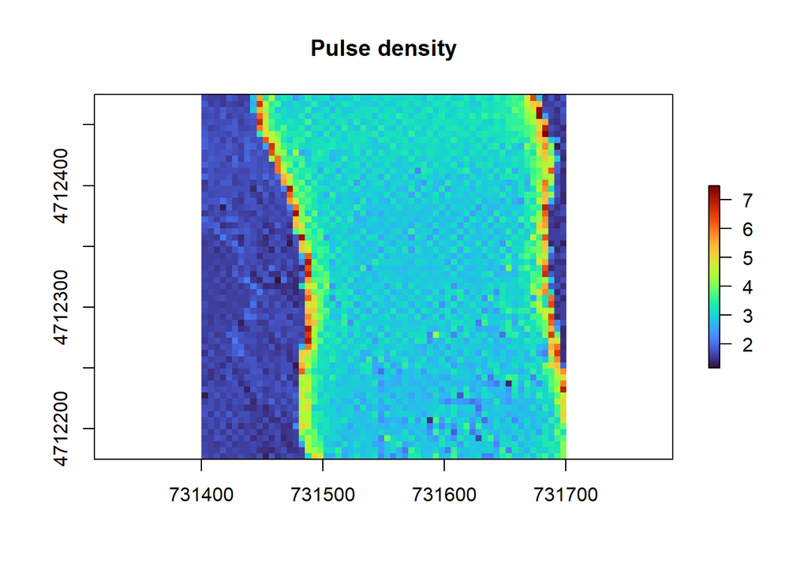

Pulse density map showing variation across the scan area

```r
# evaluate pulse density
# set desired resolution of rasterization
res_pd = 5
pd = grid_metrics(las, ~sum(ReturnNumber == 1), res = res_pd) # calculate the sum of first returns in each 5 x 5 m2 window
pd = pd / (res_pd * res_pd) # normalize by area (pd per sqm)
plot(pd, col = viridis(100, option = "turbo"), main = "Pulse density")
```

**NotePulse Density Patterns**

Notice how pulse density can vary strongly within scans - airplanes fly back and forth and some areas are sampled twice (much higher pulse density in the centre of the map), while areas underneath the plane may only be sampled once (left and right side).

Based on our own research:

- Areas with pulse densities < 2 are not sufficiently sampled for high resolution analysis (~ 1m)
- Pulse densities > 5 are generally recommended
- > 10-15 in very dense forests
- If scanners have a low ground penetration rate (most pulses only generate one return), higher pulse densities may be necessary

You can also check out the scan angle. We plot the absolute scan angle to identify areas where points are mostly scanned from oblique angles.

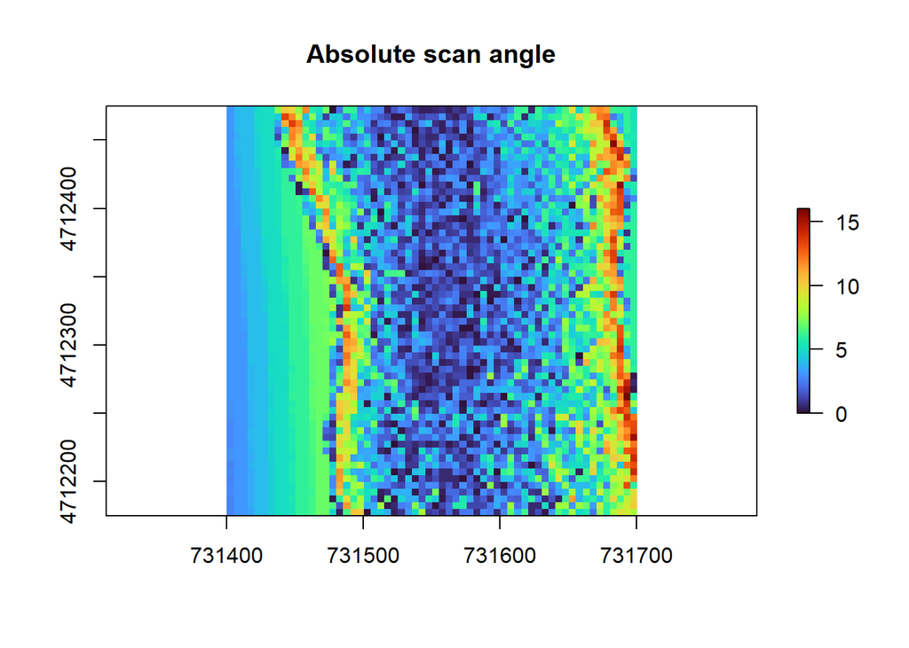

Absolute scan angle map

```r
# evaluate scan angle
# set desired resolution of rasterization
scanangle = grid_metrics(las, ~abs(mean(ScanAngleRank)), res = 5)
plot(scanangle, col = viridis(100, option = "turbo"), main = "Absolute scan angle")
```

### 4.2 Digital Terrain Model / Ground Classification

A key requirement of most ALS-based analysis is to derive a high-resolution model of the terrain, a so-called digital terrain model (DTM).

**TipDTM Recommendations**

A few recommendations:

- use default classification provided by companies / agencies that acquired data
- if you need to classify yourself, use commercial software
- if no access to commercial software, use Cloth Simulation Filter (CSF)
- evaluate uncertainties

First, we check ground classification for a single tile:

```r
# check classifications
las@data[,.N,Classification] # ground classification is 2, noise is 7
```

```
   Classification      N
            <int>  <int>
1:              5 457150
2:              2  46679
3:              1  23590
4:              7      7
```

```r
plot(las, color = "Classification", size = 3, bg = "white")
```

Then, we derive a digital terrain model for the tile:

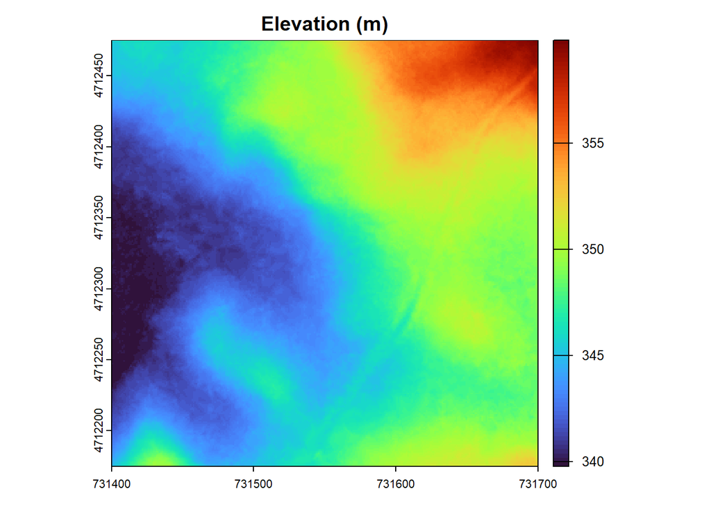

```r
# derive the DTM
dtm = rasterize_terrain(las, res = 1, algorithm = tin(), use_class = 2L)
plot(dtm, col = viridis(100, option = "turbo"), main = "Elevation (m)")
```

### 4.3 Digital Surface Model and Canopy Height Model

A canopy height model (CHM) shows the height of the vegetation above the ground. It is calculated as the difference between a digital surface model (DSM, height of the canopy) and the digital terrain model (DTM, height of the ground).

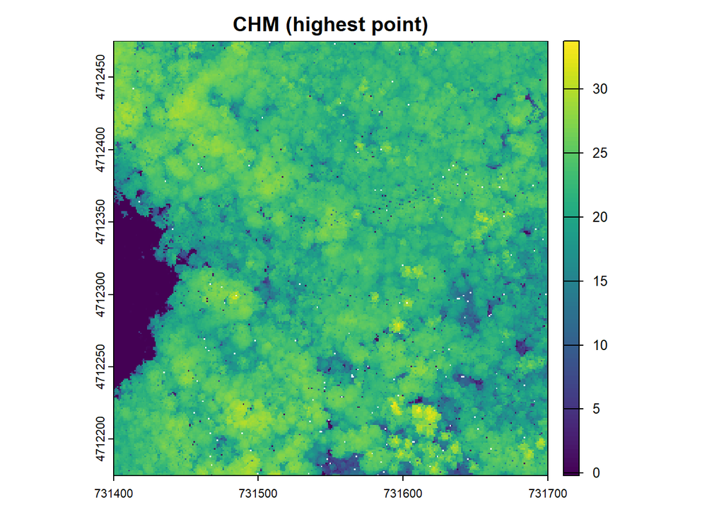

Canopy Height Model using highest point method

```r
# remove noise (class 7 and 18)
las_nonoise = filter_poi(las, Classification != 7L & Classification != 18L)

# create CHM (use highest point per grid cell)
dsm_highest = rasterize_canopy(las_nonoise, res = 1, algorithm = p2r())
chm_highest = dsm_highest - dtm
plot(chm_highest, main = "CHM (highest point)")
```

**WarningCHM Limitations**

Notice that there are a few NA values and a few small “holes” in the CHM. This happens often with “highest point” CHMs when the scan quality is low. They are generally susceptible to differences in pulse density and should be avoided for comparisons across scans.

Now we create another CHM, but interpolate the canopy with a so-called Delaunay-triangulation (create a mesh of triangles between the nearest points in xy space). When applied only to the first returns, this is a robust (albeit not always aesthetically pleasing) way of inferring canopy height.

**NoteTIN Preprocessing**

Note that lidR by default carries out a pre-selection of “highest” points before the interpolation. In our experience, this makes the CHM less robust, so it needs to be specifically deactivated.

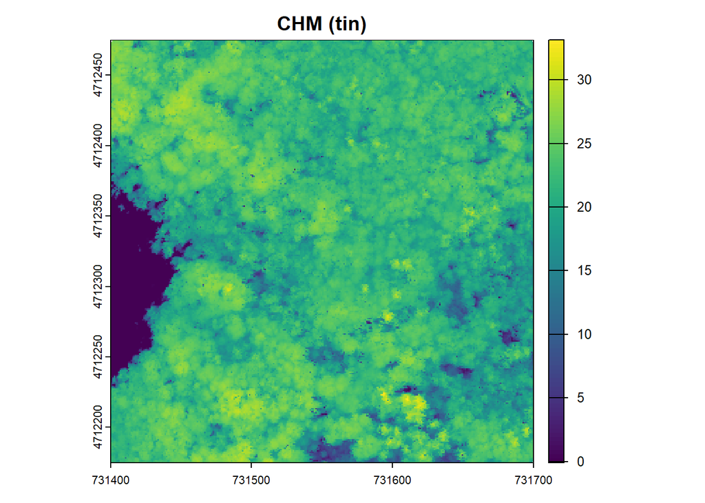

Canopy Height Model using TIN method

```r
# create a more robust CHM by using only first returns
las_nonoise_first = filter_first(las_nonoise)
dsm_tin = rasterize_canopy(las_nonoise_first, res = 1, algorithm = dsmtin(highest = FALSE))
chm_tin = dsm_tin - dtm
plot(chm_tin, main = "CHM (tin)")
```

Now plot the difference between the two CHMs:

```r
# compare the differences between the two CHMs
chm_diff = chm_highest - chm_tin
(mindiff = as.numeric(global(chm_diff, "min", na.rm = T)))
```

```
[1] -27.055
```

```r
(maxdiff = as.numeric(global(chm_diff, "max", na.rm = T)))
```

```
[1] 22.58
```

```r
(meandiff = as.numeric(global(chm_diff, "mean", na.rm = T)))
```

```
[1] 0.4274639
```

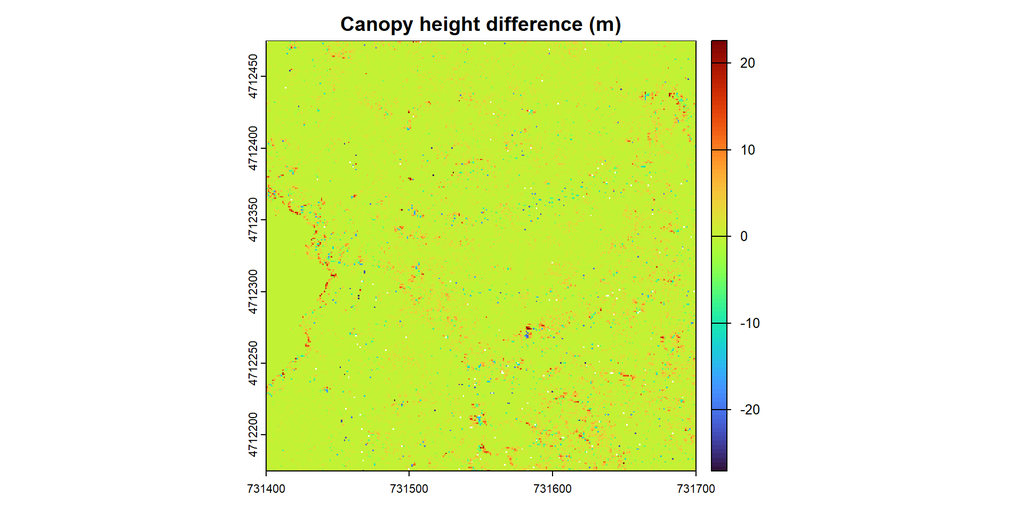

Comparison of CHM methods

```r
plot(chm_diff, col = viridis(100, option = "turbo"), main = "Canopy height difference (m)")
```

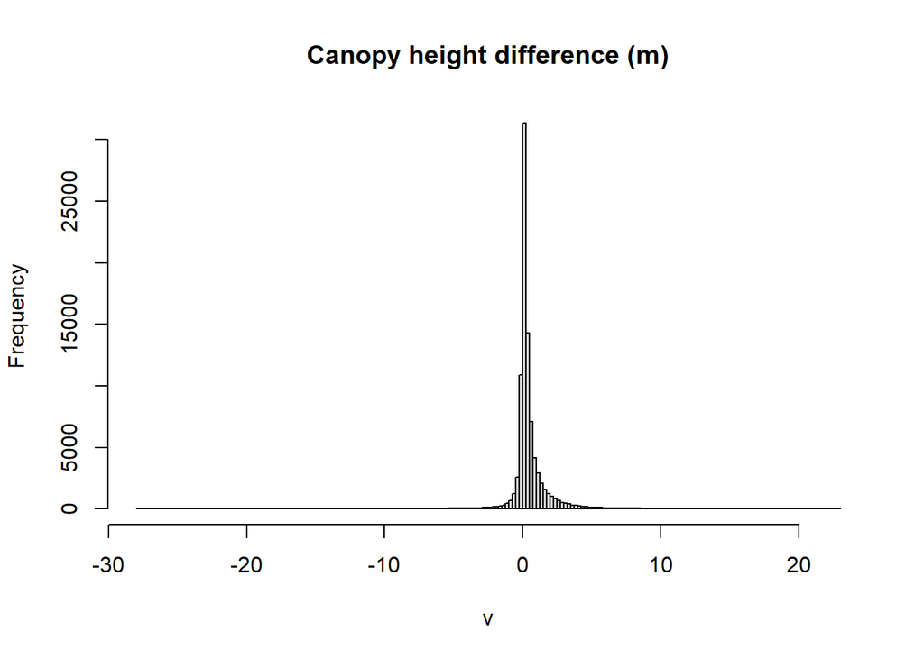

Distribution of CHM differences

```r
hist(chm_diff, main = "Canopy height difference (m)", breaks = seq(floor(mindiff), ceiling(maxdiff), 0.25))
```

### 4.4 Understanding CHM Algorithm Robustness and Stability

The choice of CHM algorithm has important implications for both the visual quality of your canopy height model and its robustness to changes in data quality. This section explores these trade-offs in detail.

#### 4.4.1 Visual Quality vs. Robustness Trade-off

**NoteKey Insight from Global Analysis**

From processing airborne laser scanning data globally across different forest types and sensor configurations, we’ve found that **the “highest point” CHM looks visually appealing and preserves fine-scale canopy structure well, but it degrades significantly when pulse density decreases**.

In contrast, **the TIN-based CHM is more robust to changes in pulse density** and remains stable even with lower-quality scans, though it may not capture small-scale canopy details as well.

#### 4.4.2 Example: Robson Creek, Australia

Let’s examine a concrete example from an ecological super site in Australia (Robson Creek) where we compared different CHM algorithms across simulated decreases in sampling intensity:

**Algorithms compared:** 1. **“Highest point” algorithm** - Takes the highest point within each pixel 2. **TIN (Triangulated Irregular Network)** - Interpolates between first returns using triangulation 3. **Spike-free algorithm** (custom robust version) - Attempts to preserve the visual quality of “highest” while maintaining stability

**WarningPhenological Effects in TIN CHMs**

An interesting observation: **TIN-based CHMs can sometimes capture phenological signals**. For example, in the Robson Creek scan (conducted during dry season onset), some trees had already lost leaves. The TIN algorithm picked up this change, showing slightly lower canopy heights for these trees compared to the “highest” algorithm which might still be influenced by a few remaining high leaves.

This means TIN CHMs may be more sensitive to seasonal timing of acquisition!

#### 4.4.3 Impact on Ecological Metrics: Gap Analysis Example

The choice of CHM algorithm doesn’t just affect visual appearance - **it fundamentally changes the interpretation of ecological metrics**. Here’s a striking example:

**Setup:** Calculate canopy gaps in a tropical forest - **Gap definition:** Everything below 50% of mean height - **Example:** If mean forest height is 20m, gaps are areas < 10m

**Results with different algorithms:**

| Algorithm | Estimated Gaps per km² | Stability at Low Pulse Density |
| --- | --- | --- |
| **Spike-free (robust)** | ~1,000 gaps | High - remains stable |
| **TIN** | ~2,000 gaps | High - remains stable |
| **Highest point** | Increases dramatically | Low - unreliable at low density |

**ImportantCritical Implications**

**Within a single site:** You can work with any algorithm consistently, though you need to be aware of what you’re measuring.

**Across multiple sites or sensors:** Algorithm choice becomes critical! You might inadvertently measure **differences between algorithms or sensors** rather than actual ecological differences between sites.

**The pattern:** - Both TIN and spike-free algorithms remain stable as pulse density decreases - The “highest point” algorithm shows a massive increase in detected gaps at low pulse density - This happens because lower sampling creates more apparent gaps that aren’t real

#### 4.4.4 Algorithm Selection Guidelines

**TipWhen to Use Each Algorithm**

**Use “highest point” CHM when:** - Working within a single, high-quality scan (> 10 pulses/m²) - Visual detail and structure preservation are critical - Not comparing across different sensors or time periods - Primarily interested in top-canopy metrics (maximum height, percentiles)

**Use TIN-based CHM when:** - Comparing across different sensors or acquisitions - Working with variable or lower pulse density (< 5 pulses/m²) - Calculating gap metrics or spatial connectivity - Need maximum robustness and reproducibility - Working across multiple sites or in operational settings

**Use spike-free or custom robust algorithms when:** - Need both visual quality AND robustness - Working on research requiring reproducibility across conditions - Comparing temporal changes (growth, disturbance)

**NoteTop Canopy Metrics Are More Stable**

**Good news:** Regardless of algorithm choice, **metrics based on top-canopy height** (maximum height in a hectare, 95th percentile height, mean of top 10% of heights) tend to be quite stable and less sensitive to algorithm choice.

**Be cautious with:** Gap metrics, spatial connectivity measures, structural complexity metrics - these are much more sensitive to algorithm choice and should only be compared within consistent processing pipelines.

#### 4.4.5 What We Use in Our Research

For the global ALS analysis presented earlier, we typically:

1. Calculate **THREE CHM versions** for each scan:
   - TIN-based (for robustness and cross-site comparison)
   - Spike-free (for research requiring both quality and robustness)
   - Highest-point (for comparison with historical literature)
2. **Primarily use TIN and spike-free** for actual analysis
3. Keep highest-point as a **reference for comparison** with other studies

**Making data available:** For most of the open ALS data shown in the theory presentation, we plan to make these pre-processed, robust CHM products publicly available on a server in the coming months.

### 4.5 Processing of Entire ALS Collection

Usually, we do not just want to process data with a single small point cloud, but large areas (e.g., many square kilometres). In this case, we can read the tiles in all together as LAScatalog:

```r
# read in a full catalog of LAS files
las_ctg = readLAScatalog("data/NEON/2012")
```

```r
# evaluate summary statistics
print(las_ctg)
```

```
class       : LAScatalog (v1.3 format 1)
extent      : 731000, 733000, 4712000, 4716000 (xmin, xmax, ymin, ymax)
coord. ref. : WGS 84 / UTM zone 18N
area        : 8 km²
points      : 37.88 million points
type        : airborne
density     : 4.7 points/m²
density     : 2.4 pulses/m²
num. files  : 8
```

```r
summary(las_ctg)
```

```
class       : LAScatalog (v1.3 format 1)
extent      : 731000, 733000, 4712000, 4716000 (xmin, xmax, ymin, ymax)
coord. ref. : WGS 84 / UTM zone 18N
area        : 8 km²
points      : 37.88 million points
type        : airborne
density     : 4.7 points/m²
density     : 2.4 pulses/m²
num. files  : 8
proc. opt.  : buffer: 30 | chunk: 0
input opt.  : select: * | filter:
output opt. : in memory | w2w guaranteed | merging enabled
drivers     :
 - Raster : format = GTiff  NAflag = -999999
 - stars : NA_value = -999999
 - Spatial : overwrite = FALSE
 - SpatRaster : overwrite = FALSE  NAflag = -999999
 - SpatVector : overwrite = FALSE
 - LAS : no parameter
 - sf : quiet = TRUE
 - data.frame : no parameter
```

```r
las_check(las_ctg)
```

```
 Checking headers consistency
  - Checking file version consistency... ✓
  - Checking scale consistency... ✓
  - Checking offset consistency... ✓
  - Checking point type consistency... ✓
  - Checking VLR consistency... ✓
  - Checking CRS consistency... ✓
 Checking the headers
  - Checking scale factor validity... ✓
  - Checking Point Data Format ID validity... ✓
 Checking preprocessing already done
  - Checking negative outliers...
    ⚠ 8 file(s) with points below 0
  - Checking normalization... no
 Checking the geometry
  - Checking overlapping tiles... ✓
  - Checking point indexation... no
```

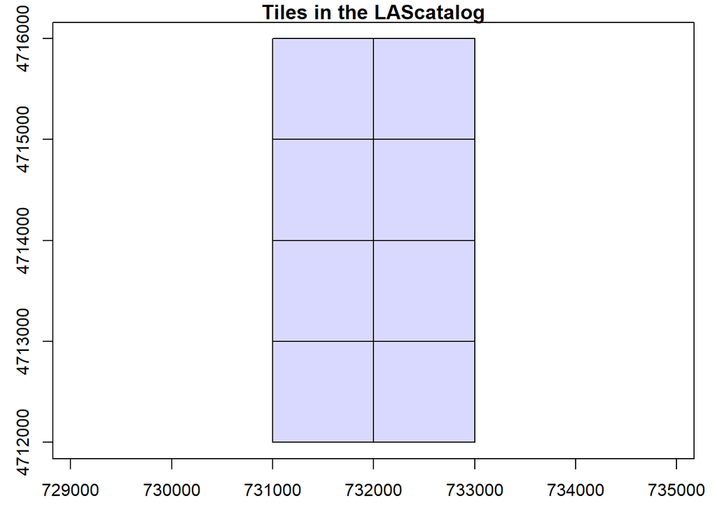

```r
plot(las_ctg, main = "Tiles in the LAScatalog")
```

We can plot pulse density for the entire scan area. Note that this will take a bit of time on your computer. To speed it up, we use parallel processing.

```r
# rasterize pulse density
# we pick a coarser resolution than before
res_pd = 20

# we process on 4 cores
# Set up a parallel plan (adjust number of workers as needed)
plan(multisession, workers = 4)   # if it creates problems, deactivate

pd = grid_metrics(las_ctg, ~sum(ReturnNumber == 1), res = res_pd) # calculate the sum of first returns
```

```r
pd = pd / (res_pd * res_pd) # normalize by area (pd per sqm)
```

Plot the pulse density:

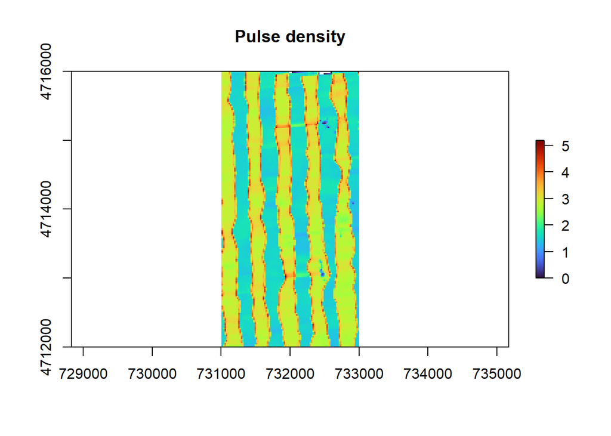

Pulse density across the entire study area

```r
# plot it again
plot(pd, col = viridis(100, option = "turbo"), main = "Pulse density")
```

Now we rasterize a DTM for the entire area:

```r
# derive digital terrain model
dtm_ctg = rasterize_terrain(las = las_ctg, res = 1, algorithm = tin(), use_class = 2L)
```

Plot the DTM:

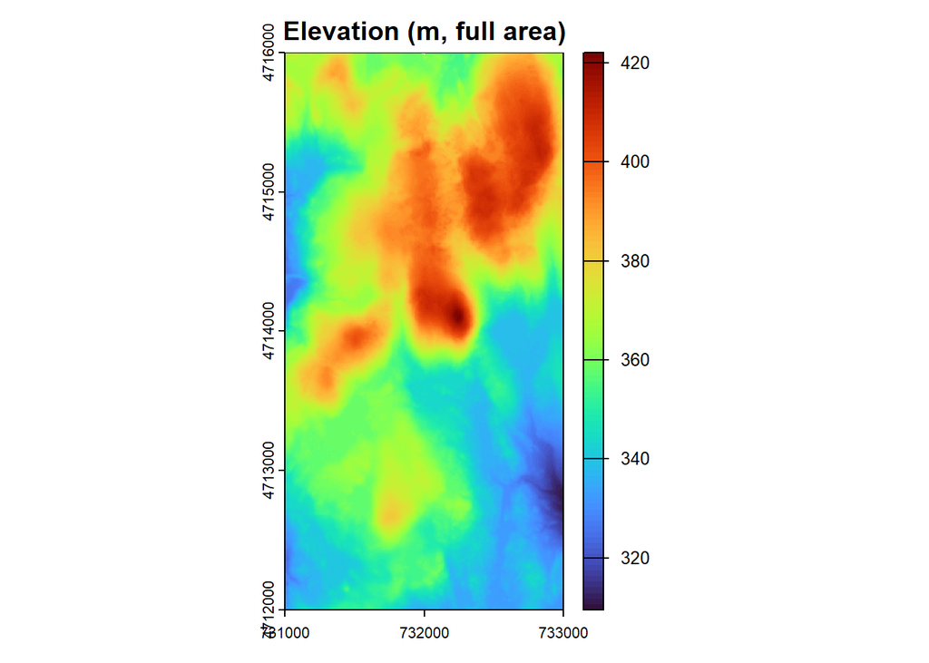

Digital Terrain Model for the full study area

```r
# plot DTM
plot(dtm_ctg, col = viridis(100, option = "turbo"), main = "Elevation (m, full area)")
```

Now we rasterize a CHM for the entire area:

```r
# derive a canopy height model
# now we also restrict only to first returns and drop noise classes --> this works differently for LAScatalog
opt_filter(las_ctg) = "-keep_first -drop_class 7 18"
dsm_ctg_tin = rasterize_canopy(las_ctg, res = 1, algorithm = dsmtin(highest = FALSE))
```

```r
chm_ctg_tin = dsm_ctg_tin - dtm_ctg
```

Plot the CHM:

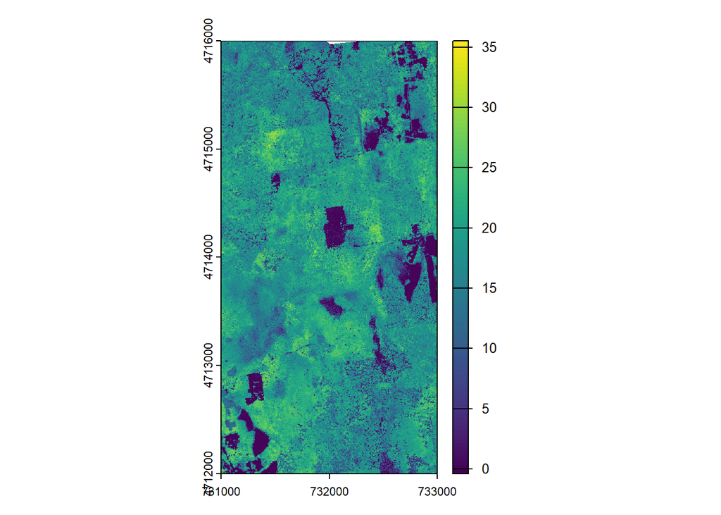

Canopy Height Model for the full study area

```r
# plot the CHM
plot(chm_ctg_tin)
```

### 4.6 Analysis: Forest Structure at Harvard Forest

**What is the typical forest height?**

The best way to find out is to use the CHM, and functions implemented in the “terra” package in R. Here’s a few functions that might be helpful:

**TipUseful Terra Functions**

```r
# check functions
?terra::global # calculate statistics for the entire raster
?terra::clamp # restrict the range of the data
?terra::zoom # zoom into a specific place, use only after terra::plot
?terra::draw # draw a polygon
?terra::crop # crop a scan to a polygon extent
?terra::mask # mask out areas with a polygon
?terra::extract # extract properties with a polygon
```

### 4.7 Tree-Based Analysis (Optional)

#### 4.7.1 Using an Existing Data Set

We can use an existing dataset (https://zenodo.org/records/10926344) of AI-predicted tree crowns in the area. Note that the tree crowns were derived in 2022, so there is a 10 year difference to the scan date. Also note that the AI-derived tree crown extensions are given as rectangles. This is just an approximation.

```r
# load pre-classified tree layer
trees = vect("data/trees_Weinstein2022/2022_HARV.shp")
trees = crop(trees, ext(chm_tin))
plot(crop(chm_tin, ext(chm_tin) * 0.1))
plot(crop(trees,ext(chm_tin) * 0.1), cex = 0.5, add = T)
```

We can also extract crown height (mean/max) from different CHMs:

```r
# extract tree height
trees$height_tin_mean = terra::extract(chm_tin, trees, fun = "mean", ID = F)
trees$height_tin_max = terra::extract(chm_tin, trees, fun = "max", ID = F)
trees$height_highest_mean = terra::extract(chm_highest, trees, fun = "mean", ID = F)
trees$height_highest_max = terra::extract(chm_highest, trees, fun = "max", ID = F)

ggplot() +
  geom_histogram(data = as.data.table(trees), aes(x = height_tin_mean), fill = "red", alpha = 0.5) +
  theme_classic() +
  xlab("Tree height (m)")
```

#### 4.7.2 Raster-Based Tree Segmentation

We can also segment trees ourselves. The idea is to first find tree tops and then segment trees. The approach works generally well in more open canopies, specifically conifer-dominated ones, but the approach does not work as well in closed canopy mixed and broadleaf forests. Trees are self-similar, so it is very hard to distinguish branches from crowns, or trees from each other.

**ImportantTree Segmentation Challenges**

**A simple test:** If segmenting trees would be hard manually/visually, an AI/deterministic algorithm will probably not do better.

**A general guideline:** The best segmentations are usually achieved with:

- high-resolution photography (< 20 cm resolution), or
- a combination of photography and laser scanning point clouds

```r
# now we try our own tree segmentation
kernel = matrix(1,5,5)

# remove noisy pits and spikes
chm_tin_smoothed = terra::focal(chm_tin, w = kernel, fun = median, na.rm = TRUE)

# locate tree tops
ttops_tin = locate_trees(chm_tin, lmf(5))

# plot CHM + tree tops
plot(crop(chm_tin, ext(chm_tin) * 0.1))
plot(crop(vect(ttops_tin),ext(chm_tin) * 0.1), col = "black", cex = 0.5, add = T)
```

Try again, now with “highest” CHM (note: not robust to pulse density, but can be better for preserving canopy structure).

```r
# repeat with highest CHM
kernel = matrix(1,5,5)
chm_highest_smoothed = terra::focal(chm_highest, w = kernel, fun = median, na.rm = TRUE)
ttops_highest = locate_trees(chm_highest, lmf(5))

plot(crop(chm_highest, ext(chm_highest) * 0.1))
plot(crop(vect(ttops_highest),ext(chm_highest) * 0.1), col = "black", cex = 0.5, add = T)
```

Then we segment the trees:

```r
# now segment tree crowns around the tree tops
algo_tin = dalponte2016(chm = chm_tin, treetops = ttops_tin)
algo_highest = dalponte2016(chm = chm_highest, treetops = ttops_highest)

# this uses the CHM to delineate crowns, a point cloud could also be used
trees_tin = rast(algo_tin()) # segment point cloud
trees_highest = rast(algo_highest()) # segment point cloud

# plot results
plot(trees_tin, col = pastel.colors(200))
```

```r
plot(trees_highest, col = pastel.colors(200))
```

Also convert to polygons:

```r
# convert to polygons / SpatVector data
trees_tin = as.polygons(trees_tin)
trees_highest = as.polygons(trees_highest)

# plot results
plot(chm_tin)
plot(trees_tin,, cex = 0.5, add = T)

plot(chm_highest)
plot(trees_highest, cex = 0.5, add = T)
```

**How stable are these segmentations?**

## 5 Summary and Key Takeaways

**Data Quality**

- Always check pulse density before analysis
- Evaluate scan angle and coverage patterns
- Remove noise and outliers systematically
- Consider temporal effects when comparing scans

**Processing Workflow**

- Start with ground classification (DTM)
- Create robust canopy height models (CHM)
- Use TIN method for more stable results
- Validate results across different methods

**Tree Detection**

**Automated segmentation works best with:**

- Open canopy forests
- High pulse density scans (> 10 pulses/m²)
- Conifer-dominated stands
- High-resolution photography integration

**Challenges:**

- Closed canopy mixed forests
- Self-similar tree structures
- Distinguishing branches from crowns

**Best Practices**

- Prefer upper canopy data over within-canopy data
- Use simple metrics over complex ones
- Always conduct sensitivity analyses
- Document all processing steps
- Validate with field measurements when possible

## 6 Conclusion

This tutorial provides a practical workflow for processing airborne laser scanning (ALS) data in R using the lidR and terra packages. The methods demonstrated here can be applied to various forest structure analyses and remote sensing applications.

The key steps covered include:

1. **Data quality assessment** - evaluating pulse density and scan characteristics
2. **Terrain modeling** - creating digital terrain models using ground-classified points
3. **Canopy analysis** - generating canopy height models using different algorithms
4. **Tree detection** - locating individual trees and segmenting crowns

**NoteNext Steps**

To further develop your ALS processing skills:

- **Temporal analysis**: Compare multiple scans over time to detect forest changes
- **Structural metrics**: Calculate additional forest structure metrics (e.g., LAI, canopy cover, vertical profiles)
- **Integration**: Combine ALS with other remote sensing data (multispectral, hyperspectral)
- **Validation**: Conduct field surveys to validate remote sensing products
- **Automation**: Develop scalable processing pipelines for operational monitoring

## 7 Additional Resources

- **lidR handbook**: https://r-lidar.github.io/lidRbook/
- **NEON tutorials**: https://www.neonscience.org/resources/learning-hub/tutorials/lidar-basics
- **LAStools**: https://rapidlasso.de/product-overview/
- **Terra package**: https://rspatial.org/terra/

*This tutorial was designed to provide hands-on experience with ALS data processing, focusing on practical applications in forest structure analysis. The modular approach allows adaptation to specific research questions and study systems.*